# OHAWE – Offene Hardware fürs Handwerk

[figure not shown]

[figure not shown]

[figure not shown]

Werkstattprojekt im T!Raum OSHOP

# OHAWE

Open Source Hardware im Handwerk —  
Selbstsouveränität der deutschen Wirtschaft

Stefan Helmert

Fakultät Informatik / Mathematik, HTW Dresden

OSHOP-Strategiemeeting · November 2026

## Hightech im Handwerk

Worum es heute geht

Nicht nur Hammer und Feile: Handwerksbetriebe setzen moderne Fertigung ein — und zwar längst.

Zahntechnik

Ein Dentallabor mit zwölf Mitarbeitenden fertigt 80 % digital und druckt rund 300 Modelle im Monat.

Quelle: dental.formlabs.com, Anwenderbericht 2024

Tischlerei

Tischlerei Müller (Duderstadt) rüstet 2025 auf 5-Achs-CNC und Fenster-CNC um — für Einzelteil-Komplettbearbeitung.

Quelle: bm-online.de, Reportage 2025

Metallbau

Ein Leipziger Handwerksbetrieb investiert 2022 in ein 5-Achs-Bearbeitungszentrum — für Einzel- und Kleinserien.

Quelle: aischmann.de, Firmenchronik 2022

**Für kleinere Handwerksbetriebe oft unattraktiv:**

hohe Komplexität hohe Investitionskosten mangelnde Flexibilität fehlendes Fachwissen geringe Stückzahlen

Problem › zwei Betriebe › offene Baupläne › Maschinen › Ihre Sicht

## Das Handwerk steckt in der Automatisierungskrise

Ausgangslage

**56 %** der Betriebe nennen Fachkräftemangel als größte Herausforderung

**−9,1 %** Tischlereibetriebe im Kammerbezirk Dresden seit 2020

**76 %** investieren weniger als 5.000 € pro Jahr in Hard- und Software

**15 %** sehen steigenden Automatisierungs- und Digitalisierungsdruck

Das Handwerk braucht unsere Unterstützung.

## Die Not machte erfinderisch

Erfunden in der Werkstatt, für die Werkstatt

1886**Rohrzange, 1892 der verstellbare Schraubenschlüssel** — der Mechaniker Johan Petter Johansson baut beides in seiner Werkstatt, weil jede Mutter ein eigenes Werkzeug verlangte.*später Weltmarktartikel unter dem Namen Bahco*

1958**Spreizdübel** — der Schlosser Artur Fischer feilt ihn in seiner Werkstatt, weil Schrauben im Mauerwerk nicht halten.*Patent DE 1 097 117*

1958**Kabelbinder** — aus der Elektromontage, statt Binden mit Band und Draht.*heute in jedem Werkzeugkoffer*

Selbst bauen und selbst entwickeln war kein reiner Notbehelf — es war **Selbstverständnis**.

## Werkzeuge bauen, Vorlagen nachbauen

Das ist keine neue Idee — nur eine vergessene

~1240**Bauhüttenbuch** des Villard de Honnecourt — Risse und Konstruktionen, zwischen Bauhütten weitergegeben.*Skizzenbuch, kein Bauplan*

1588**Ramelli** veröffentlicht 195 Maschinenentwürfe — zum Nachbau, für Bauherren und Handwerker.*Kupferstiche ohne Maße*

1731**Schübler** schreibt Zimmermannskunst „denen Zimmer-Leuten zum besten” — mit Tafeln für Dächer und Hängewerke.*Lehrbuch mit Zielgruppe Handwerk*

Open Source Hardware hat eine lange Tradition. Was fehlte: **Maße, Rückfluss, Lizenz.**

[figure not shown]

Handwerker bei der Arbeit mit eigenem Werkzeug. Tafel aus „Arts et Métiers”, 19. Jahrhundert (NYPL, gemeinfrei).

## Ziele

Was OHAWE erreichen will

Ziel ist **OSH-Transferkompetenz im Handwerk**: Betriebe sollen selbst finden, prüfen, nachbauen, anpassen und veröffentlichen können.

- Lock-In-Effekte erkennen und vermeiden
- Anwendung von OSH-Entwurfsmustern und -Paradigmen, um Barrieren zu senken
- eigenständige Recherche geeigneter OSH-Teillösungen
- Nachbau und Anpassung an die eigene Werkstatt
- Veröffentlichung der eigenen Lösungen unter offener Lizenz
- Kooperation mit anderen Handwerksbetrieben, Hochschulen und OSH-Community

Nicht drei Jahre Sondermaschine — sondern ein **nachbaubarer Baukasten** und die Fähigkeit, ihn zu nutzen.

## Zwei Betriebe, Synergieeffekte nutzen

Und was wir dafür bauen

### Fensterbau König

- Silikonfuge an Holzfenstern wird von Hand gezogen
- monoton, fehleranfällig, jede Form braucht eine neue Handbewegung
- Marktlösungen sind zu unflexibel und zu teuer

**Unsere Antwort:** ein Werkzeug, das Dichtstoff dosiert aufträgt und abzieht — auf Basis der vorhandenen Maschine.

### Restauration Pohl

- alte Lackschichten werden von Hand abgetragen
- das Grundmaterial darf dabei nicht verletzt werden
- Staub und Dämpfe belasten, Erfahrungswissen geht in Rente

**Unsere Antwort:** eine CNC-Maschine, die das Werkstück automatisch vermisst und den Lack mit Laser entfernt.

## Zwischenstand — Fokus auf Software

KI findet den Fensterrahmen

Die Maschine muss den Rahmen finden, bevor sie fährt: Wir erproben offene Segmentierungsmodelle.

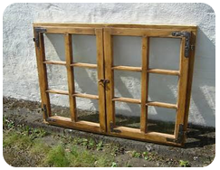

Ausgangsaufnahme

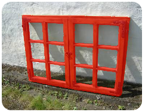

Grounding DINO + SAM 2

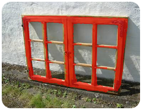

SegGPT

Noch Laborstand — aber der Schritt von der Werkzeugidee zur Maschine.

## Endergebnis (Bsp. Pohl, Laserlackentfernung)

So soll der Arbeitsplatz aussehen

- geschlossene Sicherheitszelle mit getöntem Laserschutzglas
- direkte Absaugung am Bearbeitungskopf, mehrstufige Filterung
- Lackschicht abtragen, ohne das Holz zu verletzen
- Bedienung über ein Panel, Werkstück wird vorher vermessen

Kein Schleifstaub, keine Handarbeit über Stunden — und ein Arbeitsplatz, den auch Ungelernte bedienen können.

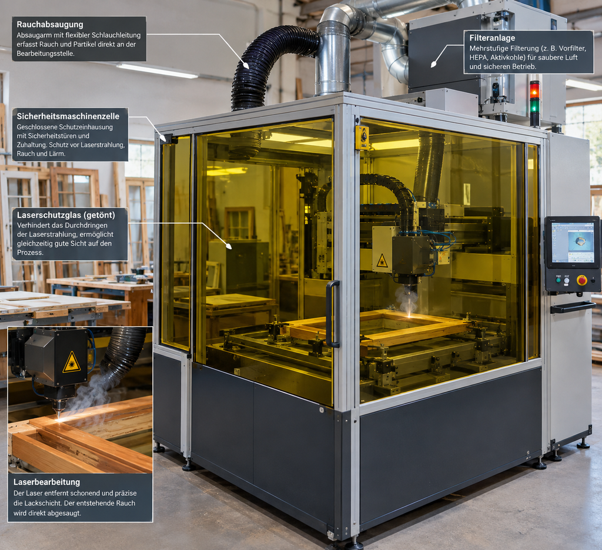

Konzeptdarstellung der Anlage — Stand vor dem Aufbau.

## Danke — Diskussion

**Stefan Helmert**  
Professur Informationsmanagement  
Fakultät Informatik / Mathematik  
HTW Dresden  
stefan.helmert@htw-dresden.de

**Projekt OHAWE**  
Open Source Hardware im Handwerk  
T!Raum OSHOP · Laufzeit 03/2026–02/2029  
Verbund: HTW Dresden, Tischlerei Pohl  
Assoziiert: Tischlerei König, Handwerkskammer Dresden

[figure not shown]

[figure not shown]

Ein Werkstattprojekt im T!Raum OSHOP. Gefördert im Rahmen der Fördermaßnahme „T!Raum — TransferRäume für die Zukunft von Regionen” des BMBF im Programm „Innovation & Strukturwandel”. Ergebnisse werden unter offener Lizenz veröffentlicht.

## Backup: Partner und Rollen

Auf einen Blick

| Partner | Rolle im Projekt |
| --- | --- |
| **HTW Dresden**, Professur Informationsmanagement | Koordination, FuE, Aufbau und Erprobung der Demonstratoren, Dokumentation, Zertifizierung |
| **Tischlerei Pohl**, Ebersbach-Neugersdorf | Anforderungen an Lackentfernung, Versuchsergebnisse/Parameter Laser-Lackentfernung, Gefährdungsbeurteilung |
| **Tischlerei König**, Rammenau | Fensterbau, stellt die vorhandene Maschine, Anforderungsmanagement, Erprobung (assoziiert) |
| **Handwerkskammer Dresden** | Multiplikator in ~21.000 Betriebe, gemeinsame Veranstaltungen mit OSHOP |